# Bandwidth Selection Methods

Charlotte Boys, Leon Patzig, Carla Sagebiel

```r
library(KDE)
```

Kernel Density Estimation (KDE) is a statistical tool to estimate the underlying probability density function given a finite set of data points. As parameters, the method takes a choice kernel and a bandwidth . Both parameters affect the ‘shape’ of the final estimate, but the bandwidth has the greatest influence and a selection of methods have been developed to make the best choice of bandwidth given a dataset and a chosen kernel.

Our package provides implementations of three such bandwidth selection methods:

- Cross validation
- Goldenschluger-Lepski
- Penalized Comparison to Overfitting (PCO)

The package also provides:

- a rejection sampling algorithm to generate simulated data from a range of provided functions, with the option to input a user-generated function
- a range of KDE kernels
- an implementation of the Kernel Density Estimator given data, bandwidth and kernel

Users are also invited to explore the package through the KDE Shiny application.

## Basic usage

### Generate a dataset with `rejection_sample()`

The user is able to provide their own data, or use `rejection_sample()` to simulate sampling from a given distribution. `rejection_sample()` has the following essential arguments:

- The first argument, `n_obs`, should be an integer giving the number of data points which should be generated.
- The second argument, `f`, is a probability density function. Users can provide their own function, or make use of one of the provided `pdf` functions (see below).

Further arguments are optional:

- `helper`: a helper function for the rejection sampling algorithm. Choose from `helpers$normal` (default) or `helpers$uniform`.
- `n_iter`: a calibration constant (default `10`). The algorithm will take an average of `n_iter` iterations to obtain a sample.

For example, we simulate 500 data points from a Cauchy distribution with location parameter `x0 = 0` and scale parameter `gamma = 0.3`:

```r
pdf <- get_cauchy(0, 0.3)
data <- rejection_sample(500, pdf)
```

### Find optimal bandwidth with `bandwidth_selection()`

`bandwidth_selection()` uses a chosen bandwidth selection method to find `h_opt`, an optimal bandwidth for use in Kernel Density Estimation. It takes the following arguments which are independent of method choice:

- The first argument, `method` is a string naming one of three bandwidth selection methods:
  - `'CV'` for Cross-validation
  - `'PCO'` for Penalized Comparison to Overfitting
  - `'GL'` for Goldenschluger-Lepski
- For the second argument, a `Kernel` should be chosen from the following list:
  - `kernels$gaussian`
  - `kernels$rectangular`
  - `kernels$triangular`
  - `kernels$epanechnikov` or alternatively `kernel$parabolic`
  - `kernels$biweight`
  - `kernels$silverman`

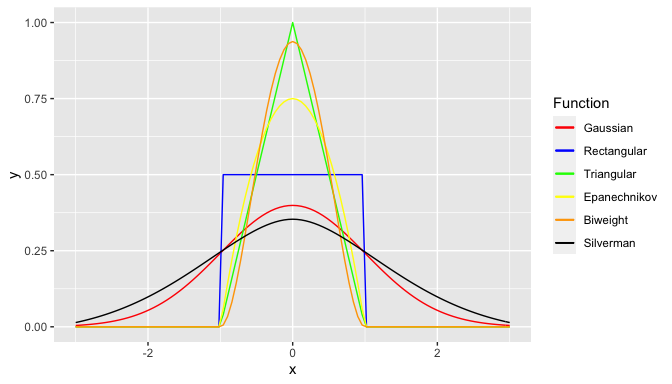

- `data` is the dataset generated with `rejection_sample()` or otherwise
- `maxEval` is the maximum number of function evaluations which `cubature::cubintegrate` will use to find an integral. Particularly for the integral-heavy Goldenschluger-Lepski method, smaller values are recommended to reduce computation time.
- `lower` (default `lower = 1e-3`) is a double value which gives the lower bound for the bandwidth search interval i.e. the smallest possible bandwidth
- Similarly, `upper` (default `upper = 1e0`) is a double value giving an upper bound for the bandwidth search interval

Further method-dependent parameters for the PCO and Goldenschluger-Lepski methods are optional:

#### PCO

- A calibration constant `v` for the variance term (default `v = 1`)

#### Goldenschluger-Lepski

- A vector of `bandwidths` to test. Default `bandwidths = NULL`.
- If `bandwidths = NULL`, a uniform sequence of bandwidths is generated within the range between `lower` and `upper`. Parameter `n_bandwidths` gives the number of bandwidths in this sequence.
- A calibration constant `c` for the the bias term (default `c = 1`)
- A calibration constant `v` for the variance term (default `v = 2`)

For the above calibration constants, it is recommended to use a ratio `v = 2c`. A minimum admissible value of `c = 1` is recommended, although this value has only been proven asymptotically (Lacour, C. and Massart, P., 2016. Minimal penalty for goldenshluger–lepski method).

We demonstrate using the Gaussian kernel and PCO bandwidth selection method:

```r
setup_cluster(use_parallel = FALSE)
kernel <- kernels$gaussian
t <- Sys.time()
Rprof()
h_opt <- bandwidth_selection('PCO', kernel, data, maxEval = 1e3)
Rprof(NULL)
Sys.time()-t
```

```
#> Time difference of 1.904699 secs
```

```r
summaryRprof()
```

[output not shown]

```r
h_opt
```

```
#> [1] 0.1654897
```

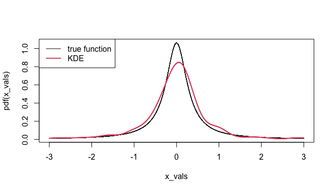

```r
KDE <- get_kde(h_opt, kernel, data)

x_vals <- seq(from = -3, to = 3, length.out = 1e5)

plot(x_vals, pdf(x_vals), col = 1, lwd = 1, type = 'l')#, xlim=c(-4,4), ylim=c(0,0.45))
lines(x_vals, KDE(x_vals), col=2, lwd=2)
legend('topleft',
       c('true function', 'KDE'),
       lwd = 1:2,
       col = 1:2)
```